# Medidas de dependencia serial y estacionariedad

v. 2025.08.24

## Dependencia serial

## Introducción

Antes de modelar una serie de tiempo, es necesario describir su comportamiento. Para esto calculamos:

1. La función promedio.
2. La función de autocovarianza.
3. La función de autocorrelación.

Veremos en qué consisten estas funciones y algunos ejemplos.

## Función promedio

La **función promedio** se define como:

\[ \mu_{y_t} = \mathbb{E}(y_t) \]

donde \(y_t\) es una serie de tiempo en el momento \(t\), \(t=1,...,T\).

## Función promedio: Ejemplos (1/2)

Considera una serie de tiempo que se comporta como:

\[ \begin{align} &y_t = \frac{1}{3}(\varepsilon_{t-1}+\varepsilon_{t}+\varepsilon_{t+1}) \\ &\varepsilon_t \sim iid \mathcal{N}(0,\sigma^2) \end{align} \]

En este caso:

\[ \begin{align} \mu_{y_t} &= \mathbb{E}(y_t)\\ &=\frac{1}{3}\left[\mathbb{E}(\varepsilon_{t-1}) +\mathbb{E}(\varepsilon_{t}) + \mathbb{E}(\varepsilon_{t+1})\right]\\ &=0 \end{align} \]

## Función promedio: Ejemplos (2/2)

Considera una serie de tiempo que se comporta como:

\[ \begin{align} y_t &= \delta + y_{t-1} + \varepsilon_t; \ y_0 = 0\\ &= \delta t + \sum_{j=1}^{t}\varepsilon_j\\ &\varepsilon_t \sim iid \mathcal{N}(0,\sigma^2) \end{align} \]

En este caso:

\[ \mu_{y_t} = \delta t \]

## Función de autocovarianza

La **función de autocovarianza** se define como:

\[ \gamma_y (t, \tau) = E[(y_t - \mu_t)(y_\tau - \mu_\tau)] \]

donde \(y_t\) es alguna serie de tiempo en el momento \(t\). Nota que si \(\tau=t\):

\[ \begin{align} \gamma(t, t) &= \mathbb{E}[(y_t - \mu_t)^2]\\ & =\mathbb{V}ar(y_t) \end{align} \]

## Función de autocovarianza: Ejemplos (1/2)

Considera una serie de tiempo que se comporta como:

\[ \begin{align} &y_t = \varepsilon_t \\ &\varepsilon_t \sim iid \mathcal{N}(0,\sigma^2) \end{align} \]

En este caso:

\[ \gamma_y(t, \tau) = \begin{cases} \sigma^2 & \text{si} \ t=\tau \\ 0 & \text{si} \ t\neq\tau \end{cases} \]

## Función de autocovarianza: Ejemplos (2/2)

Considera una serie de tiempo que se comporta como:

\[ \begin{align} &y_t = \frac{1}{3}(\varepsilon_{t-1}+\varepsilon_{t}+\varepsilon_{t+1}) \\ &\varepsilon_t \sim iid \mathcal{N}(0,\sigma^2) \end{align} \]

En este caso:

\[ \gamma_y(t, \tau) = \begin{cases} \frac{1}{3}\sigma^2 & \text{si} \ |t-\tau|=0 \\ \frac{2}{9}\sigma^2 & \text{si} \ |t-\tau|=1 \\ \frac{1}{9}\sigma^2 & \text{si} \ |t-\tau|=2 \\ 0 & \text{si} \ |t-\tau|>2 \\ \end{cases} \]

## Función de autocorrelación (1/2)

La **función de autocorrelación** se define como:

\[ \rho(t,\tau) = \frac{\gamma_y(t,\tau)}{\sqrt{\gamma_y(t,t) \gamma_y(\tau,\tau)}} \]

donde \(y_t\) es una serie de tiempo en el momento \(t\).

## Función de autocorrelación (2/2)

Nota que la función de autocorrelación se simplifica cuando la varianza de \(y_t\) es constante. Esto es, si \(\gamma_y(t,t) = \gamma_y(\tau,\tau)\), entonces:

\[ \rho(t,\tau) = \frac{\gamma_y(t,\tau)}{\gamma_y(t,t)} \]

Si además \(t=\tau\):

\[ \rho(t,\tau) = 1 \]

## Función de autocorrelación: Ejemplos (1/2)

Considera una serie de tiempo que se comporta como:

\[ \begin{align} &y_t = \varepsilon_t \\ &\varepsilon_t \sim iid \mathcal{N}(0,\sigma^2) \end{align} \]

En este caso:

\[ \rho_y(t, \tau) = \begin{cases} 1 & \text{si} \ t=\tau \\ 0 & \text{si} \ t\neq\tau \end{cases} \]

## Función de autocorrelación: Ejemplos (2/2)

Considera una serie de tiempo que se comporta como:

\[ \begin{align} &y_t = \frac{1}{3}(\varepsilon_{t-1}+\varepsilon_{t}+\varepsilon_{t+1}) \\ &\varepsilon_t \sim iid \mathcal{N}(0,\sigma^2) \end{align} \]

En este caso:

\[ \rho_y(t, \tau) = \begin{cases} 1 & \text{si} \ |t-\tau|=0 \\ \frac{2}{3} & \text{si} \ |t-\tau|=1 \\ \frac{1}{3} & \text{si} \ |t-\tau|=2 \\ 0 & \text{si} \ |t-\tau|>2 \\ \end{cases} \]

## Otras medidas de dependencia serial

Otras medidas de dependencia serial son:

- La **función de covarianza cruzada**:

\[ \gamma_{xy} (t, \tau) = E[(x_t - \mu_{x_t})(y_\tau - \mu_{y_\tau)}] \]

- La **función de correlación cruzada**:

\[ \rho_{xy} (t, \tau) = \frac{\gamma_{xy}(t,\tau)}{\sqrt{\gamma_x(t,t) \gamma_y(\tau,\tau)}} \]

## Estacionariedad

## Estacionariedad

El concepto de **estacionariedad** (débil) es importante para modelar una serie de tiempo. Una serie \(y_t\) es estacionaria si:

1. Su media es constante:

   \[ \mu_{y_t} = \mu_{y} \]
2. Su función de autocovarianza no depende de \(t\) o \(\tau\), sino de \(h = t-\tau\):

   \[ \gamma_y(t+k, \tau+k) = \gamma_y(t,\tau); \ k \ \in \ \mathbb{Z} \]

## Ejemplo de estacionariedad (1/4)

Considera un ruido blanco:

\[ \begin{align} &y_t = \varepsilon_t \\ &\varepsilon_t \sim iid \mathcal{N}(0,\sigma^2) \end{align} \]

Este proceso es estacionario puesto que:

\[ \begin{align} E(y_t) &= 0 \\ \gamma_y(t,\tau) &= \begin{cases} \sigma^2 & \text{si} \ t=\tau \ (h=0)\\ 0 & \text{si} \ t\neq\tau \ (h\neq0) \end{cases} \end{align} \]

## Ejemplo de estacionariedad (2/4)

Considera una serie de tiempo que se comporta como:

\[ \begin{align} &y_t = \frac{1}{3}(\varepsilon_{t-1}+\varepsilon_{t}+\varepsilon_{t+1}) \\ &\varepsilon_t \sim iid \mathcal{N}(0,\sigma^2) \end{align} \]

Este proceso es estacionario puesto que:

\[ \begin{align} E(y_t) &= 0 \\ \gamma_y(t, \tau) &= \begin{cases} \frac{1}{3}\sigma^2 & \text{si} \ h=0 \\ \frac{2}{9}\sigma^2 & \text{si} \ |h|=1 \\ \frac{1}{9}\sigma^2 & \text{si} \ |h|=2 \\ 0 & \text{si} \ |h|>2 \\ \end{cases} \end{align} \]

## Ejemplo de estacionariedad (3/4)

Considera un proceso autorregresivo de orden 1:

\[ \begin{align} &y_t = \phi y_{t-1} + \varepsilon_t \\ &\varepsilon_t \sim iid \mathcal{N}(0,\sigma^2) \end{align} \]

Este proceso es estacionario si \(|\phi| < 1\), ya que:

\[ \begin{align} E(y_t) &= 0 \\ \gamma_y(t,\tau) &= \begin{cases} \frac{\sigma^2}{1-\phi^2}; & |h| = 0 \\ \phi \frac{\sigma^2}{1-\phi^2}; & |h| = 1 \\ \phi^2 \frac{\sigma^2}{1-\phi^2}; & |h| = 2 \\ \vdots &\\ \end{cases} \end{align} \]

## Ejemplo de estacionariedad (4/4)

Considera una caminata aleatoria:

\[ \begin{align} y_t &= \delta + y_{t-1} + \varepsilon_t; \ y_0 = 0 ; \ \varepsilon_t \sim iid \mathcal{N}(0,\sigma^2) \\ &= \delta t + \sum_{j=1}^{t}\varepsilon_j \end{align} \]

En este caso, ambas condiciones para la estacionariedad se violan, puesto que:

\[ \begin{align} \mu_{y_t} &= \delta t\\ \gamma_y(t,\tau) &= \sigma^2\min(t,\tau) \end{align} \]

## Estacionario vs. No estacionario

¿Cuál(es) de estos procesos es (son) estacionario(s)?

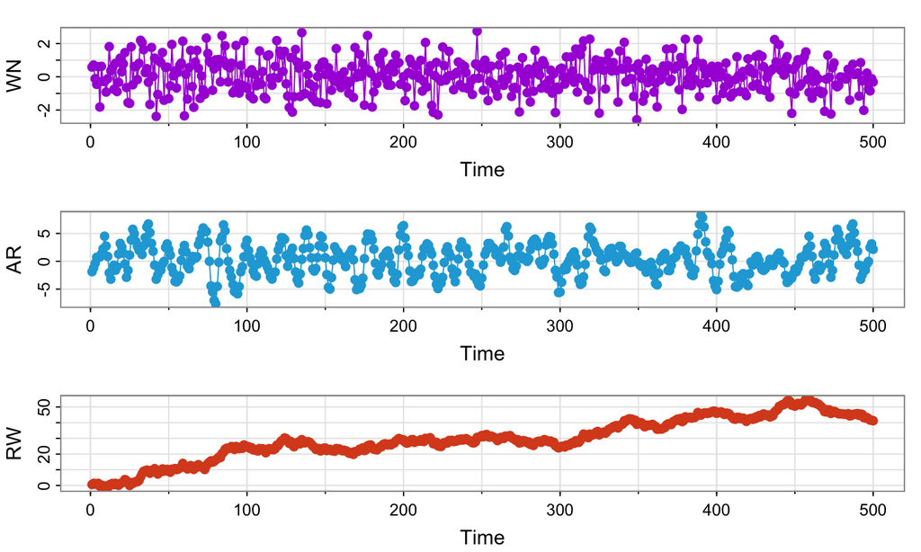

## Estacionariedad: Función promedio y autocovarianza

De los resultados anteriores, es fácil deducir que, para un proceso estacionario:

1. La función promedio:

   \[ \begin{align} \mu_y &= \mathbb{E}(y_t) \\ & = \mu \end{align} \]
2. La función de autocovarianza solo depende del desfase \(h = t-\tau\):

   \[ \begin{align} \gamma_y(t,\tau) &= \gamma_y(t,t-h) \\ &= \gamma_y(h,0) \\ &= \gamma_y(h) \\ &= \gamma_y(-h) \\ \end{align} \]

## Descomposición de Wold (1/2)

La siguiente es la **descomposición de Wold**:

Cualquier serie estacionaria \(y_t\) puede reescribirse como una combinación lineal de ruidos blancos:

\[ \begin{align} y_t &= \mu + \sum_{j=0}^\infty \psi_j \varepsilon_{t-j}, \ \sum_{j=0}^\infty\psi_j^2<\infty; \ \psi_0=1\\ \varepsilon_t &\sim iid \mathcal{N}(0,\sigma^2). \end{align} \]

## Descomposición de Wold (2/2)

Entonces, si \(y_t\) es una serie estacionaria:

\[ \mathbb{E}(y_t) = \mu. \]

Y:

\[ \gamma_y(h) = \sigma^2 \sum_{j=0}^\infty \psi_j \psi_{j+h}. \]

## Dependencia serial: estimación

## Dependencia serial: estimación (1/3)

El cálculo de las funciones promedio, autocovarianza y autocorrelación depende de nuestro conocimiento de los parámetros del modelo y del ruido blanco.

Si \(y_t\) es una serie de tiempo **ergódica**, podemos usar las observaciones \(y_1, y_2, \dots, y_T\) para estimar:

1. **Promedio muestral:**

   \[ \hat{\mu} = \frac{1}{T} \sum_{t=1}^T y_t. \]
2. **Autocovarianzas muestrales:**

   \[ \hat{\gamma}(h) = \frac{1}{T} \sum_{t=1}^{T-h} (y_t - \hat{\mu})(y_{t+h} - \hat{\mu}). \]

## Dependencia serial: estimación (2/3)

3. **Autocorrelaciones muestrales:**

   \[ \hat{\rho}(h) = \frac{\hat{\gamma}(h)}{\hat{\gamma}(0)}. \]

Se puede demostrar que si la serie \(y_t\) es un ruido blanco, entonces para \(T\) grande y bajo ciertas condiciones, la función de autocorrelación muestral se distribuye aproximadamente como:

\[ \hat{\rho}(h) \sim \mathcal{N}\left(0, \frac{1}{T}\right). \]

## Dependencia serial: estimación (3/3)

El **correlograma** es la representación gráfica de la función de autocorrelación muestral, incluyendo intervalos de confianza.

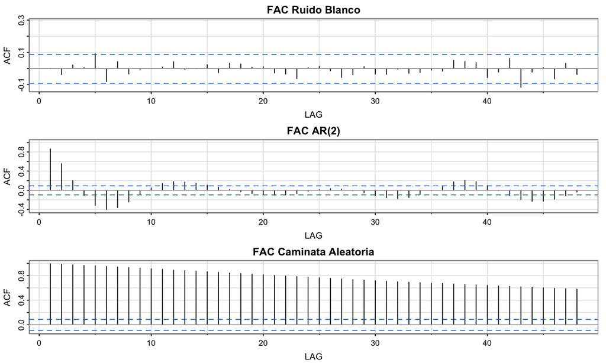

## Otras medidas de dependencia serial (1/2)

**Autocovarianza y autocorrelación cruzadas:**

\[ \hat\gamma_{xy}(h) = \frac{1}{T} \sum_{t=1}^{T-h} (x_t - \hat{\mu_x})(y_{t+h} - \hat{\mu_y}). \]

\[ \hat\rho_{xy}(h) = \frac{\hat\gamma_{xy}(h)}{\sqrt{\hat\gamma_x(0)\hat\gamma_y(0)}}. \]

Se puede demostrar que si las series \(x_t\) y \(y_t\) son independientes, entonces para \(T\) grande:

\[ \hat{\rho}_{xy}(h) \sim \mathcal{N}\left(0, \frac{1}{T}\right). \]

## Otras medidas de dependencia serial (2/2)

Algunos ejemplos:

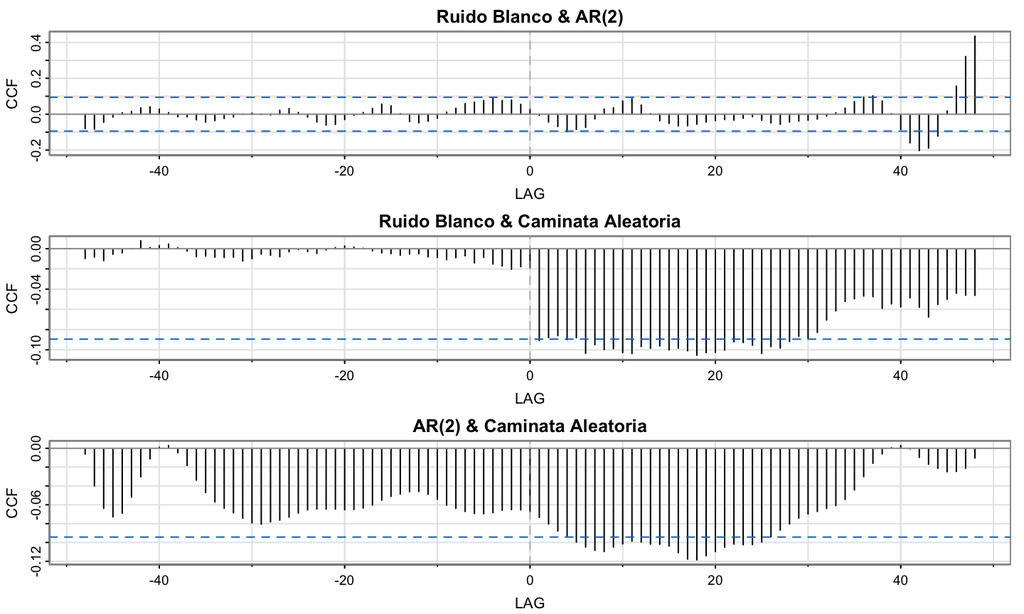

## Estacionariedad estricta y ergodicidad

## Estacionariedad estricta

El concepto de estacionariedad que hemos estudiado corresponde al de estacionariedad débil o estacionariedad en covarianza. Sin embargo, también existe el concepto de **estacionariedad estricta** o fuerte.

Una serie de tiempo, \(y_t\) es estacionaria fuerte si:

\[ f_{Y_t, Y_{t+1}, Y_{t+2},\dots}(y_t, y_{t+1}, y_{t+2},\dots) = f_{Y_{t+h}, Y_{t+h+1}, Y_{t+h+2},\dots}(y_{t+h}, y_{t+h+1}, y_{t+h+2},\dots) \]

Usualmente, *estacionariedad débil* no implica estacionariedad fuerte y viceversa.

## Ergodicidad (1/2)

En general, tenemos que la serie de tiempo \(y_t\), \(t=1,2,\dots,T\) es **ergódica en la media** si:

\[ \begin{align} \lim_{T\rightarrow\infty} \frac{1}{T}\sum_{t=1}^T y_t &= \mathbb{E}(y_t) \\ & = \mu \end{align} \]

Se puede demostrar que una *condición necesaria* para la ergodicidad es que:

\[ \sum_{j=0}^{\infty} |\gamma_y(j)|<\infty. \]

Además, esta *condición es suficiente* si \(y_t \sim iid\mathcal{N}(\cdot)\).

## Ergodicidad (2/2)

De igual forma, tenemos que la serie de tiempo \(y_t\), \(t=1,2,\dots,T\) es **ergódica en la covarianza** si:

\[ \lim_{T\rightarrow\infty} \frac{1}{T} \sum_{t=1}^{T-h} (y_t - \hat{\mu})(y_{t+h} - \hat{\mu}) = \gamma_y(h) \]

Se puede demostrar que, si \(y_t \sim iid\mathcal{N}(\cdot)\), una serie de tiempo es ergódica en covarianza si es ergódica en su media.